# Project 3: Annual Average Daily Traffic, CA, 2012 by Susan S.

Next is a set of faceted plots like one of my final plots, but it does not have a free x scale. Each plot is as wide and scaled as the county with the most mileage along highway 101. The legend is outside the plot.

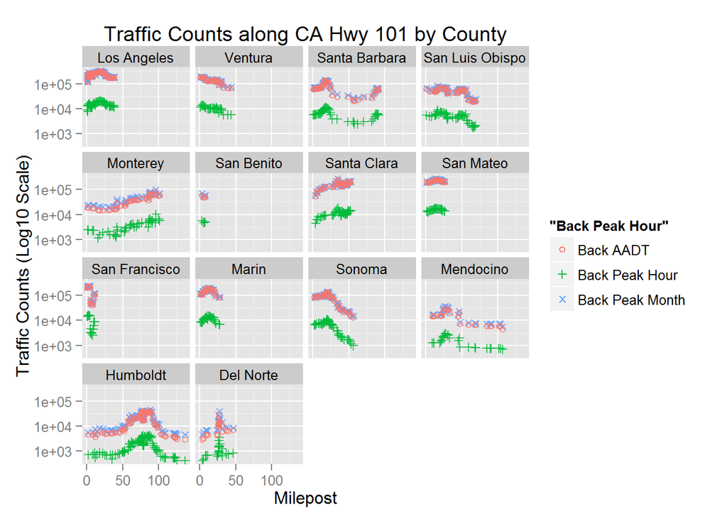

The next set of faceted plots brings the legend inside and colors it to stand out. It doesn’t provide any new information.

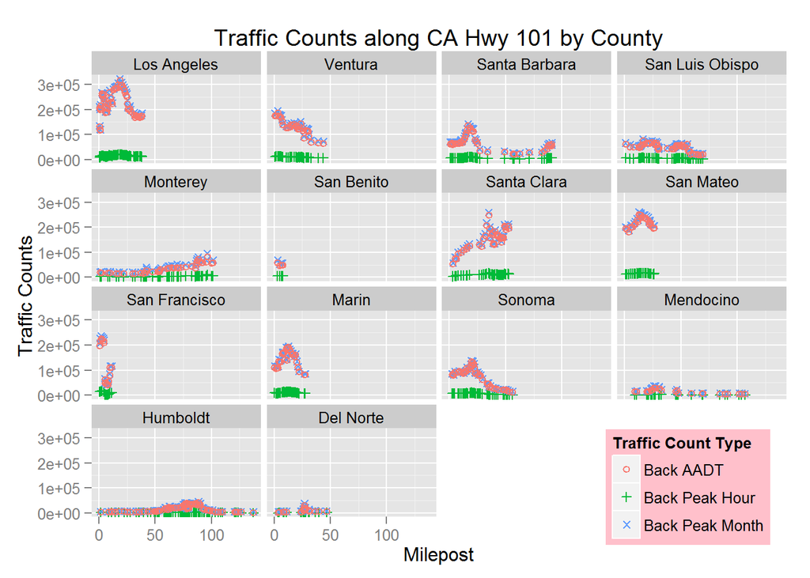

Another way to represent the traffic along highway 101 is by a boxplot by county. It shows the traffic distribution in each county. I also color-coded it by district. Adjacent counties can be in the same district. It is obvious that districts 7 and 4 have higher traffic along highway 101 than districts 5 and 1.

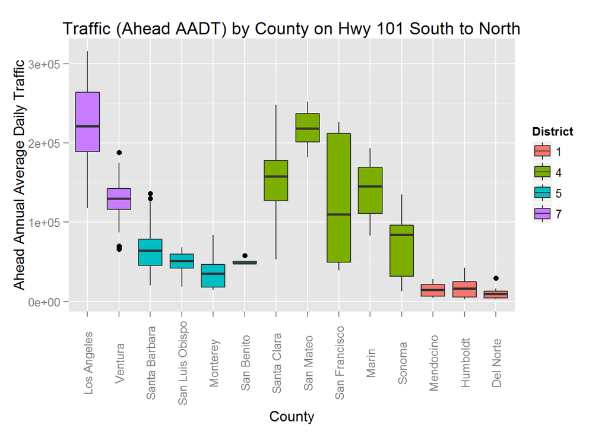

Look at traffic counts by postmile prefix per county along Highway 101: The most frequent is blank (no prefix), and the second most frequent is ‘R’, the first re-alignment. Mendocino has some ‘T’, a temporary connection. Los Angeles has some ‘S’, a spur. Del Norte also has an ‘M’, which is a realignment of ‘R’ (second realignment).

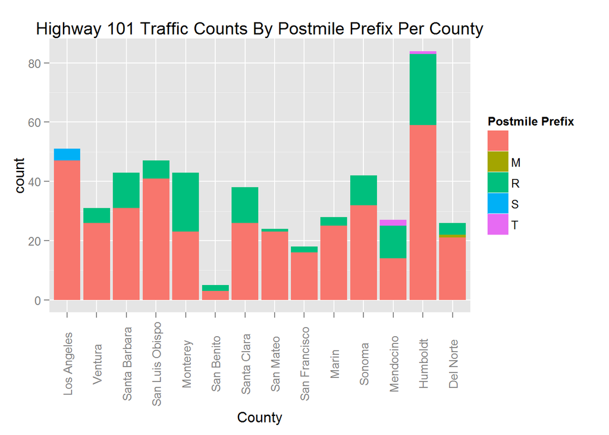

Another way to look at the postmile prefix is to graph them by amount of traffic and group by county. The spurs usually have lower traffic. Using a more divergent color scheme (I created it manually) helps.

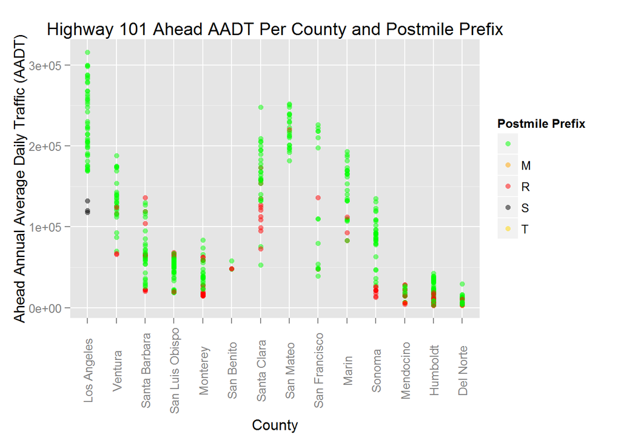

GGpairs for the traffic count variables shows the correlation.

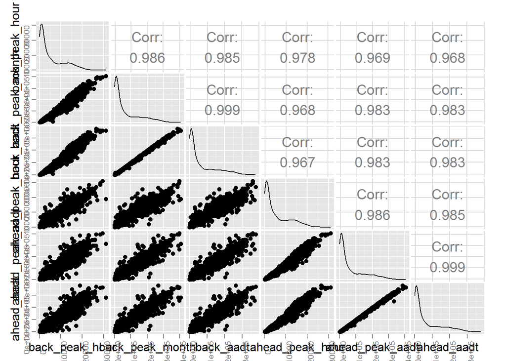

The GGpairs did not come out well. It may not be polished, but it shows the correlations. I could not find documentation on aligning column/row labels.

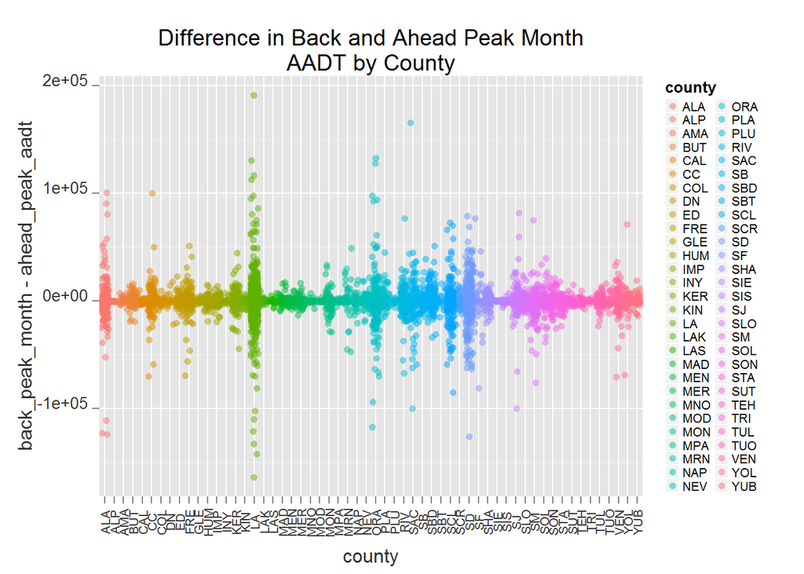

Looking at the differences in back and ahead peak month (daily) and peak hour traffic, the differences are obviously bigger over an entire day. If I had more time I would investigate by looking at the descriptions for the locations that had the biggest differences to see whether there was a large roadway at the intersection that was adding or siphoning off traffic.

Limiting the difference to Highway 101 along its cumulative mileage makes the labelling easier and reduces the clutter. We know there are big differences in San Francisco and you can see the points here.

Here are the statistics of back_peak_month - ahead_peak_aadt: (it looks normal)

```r
summary(dfp3$back_peak_month - dfp3$ahead_peak_aadt)
```

```
##      Min.   1st Qu.    Median      Mean   3rd Qu.      Max.      NA's
## -164000.0   -2500.0       0.0     173.4    3000.0  191600.0      1067
```

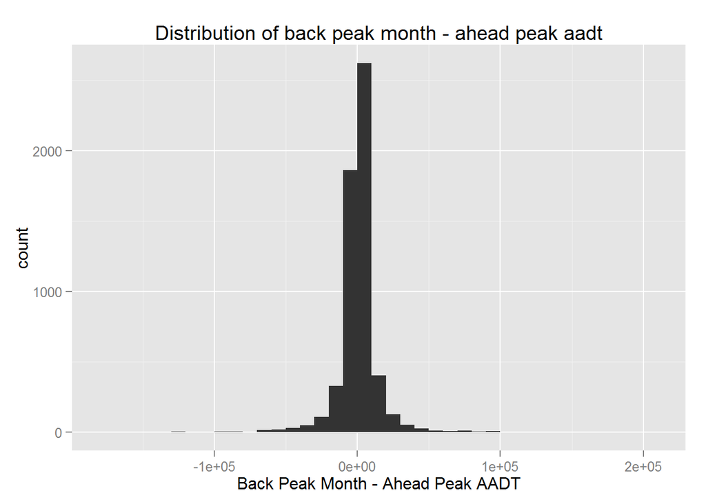

```r
qplot(dfp3$back_peak_month - dfp3$ahead_peak_aadt, binwidth = 10000) +
ggtitle("Distribution of back peak month - ahead peak aadt")  +
  xlab("Back Peak Month - Ahead Peak AADT")
```

Difference in Back and Ahead Peak Hour by County

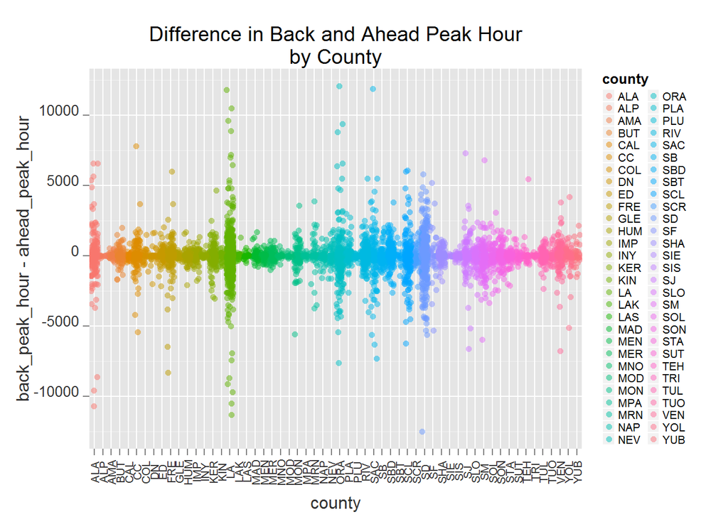

Here are the statistics of back_peak_hour - ahead_peak_hour: (it looks normal)

```
##       Min.    1st Qu.     Median       Mean    3rd Qu.       Max.
## -12500.000   -250.000      0.000      9.114    300.000  12100.000
##       NA's
##       1067
```

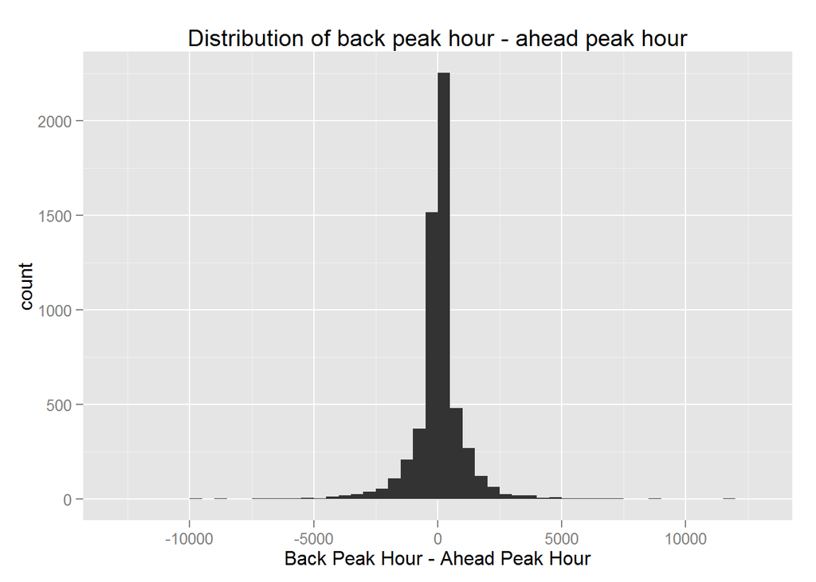

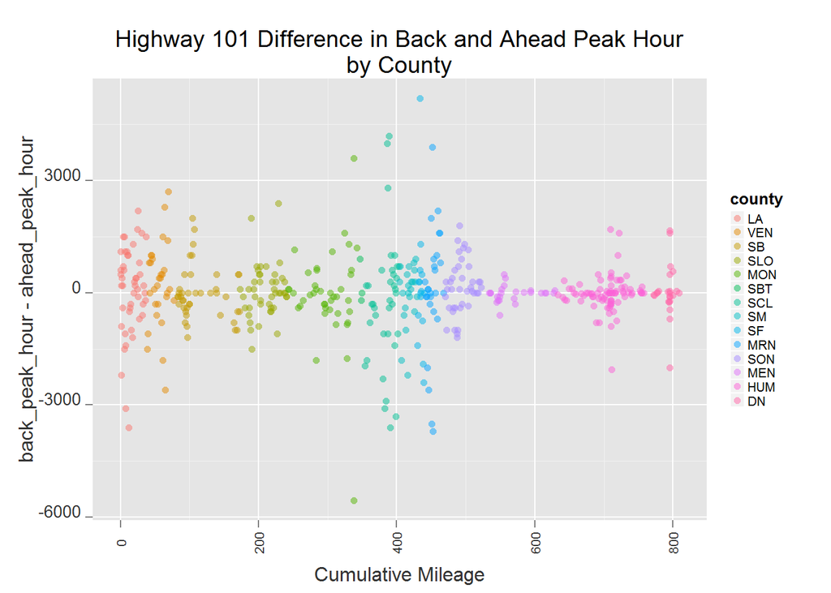

Traffic, population, by county. Here I made a new summary dataframe with back peak month mean/median/min/max/count. I added in the population.

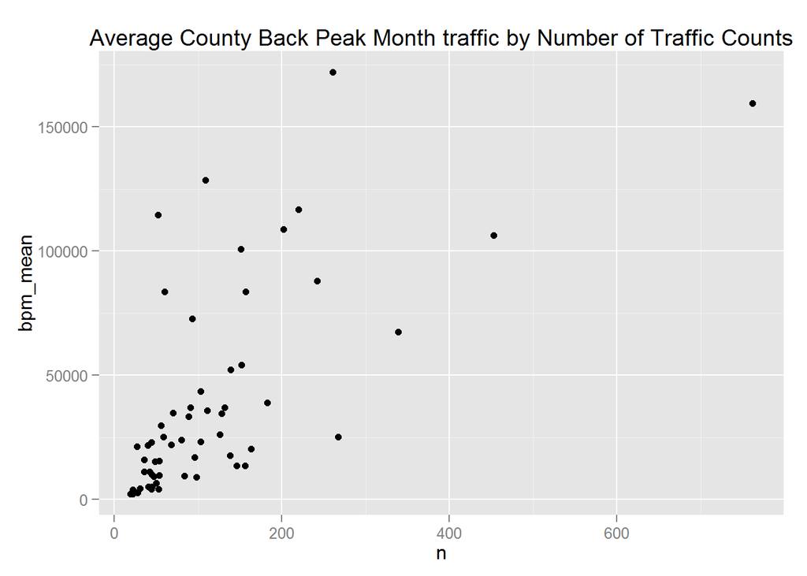

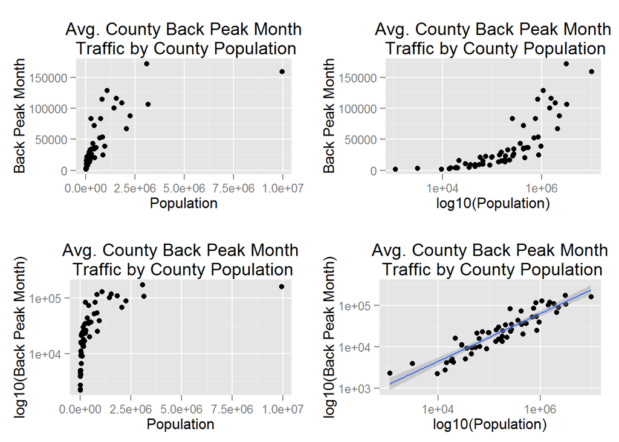

I looked at the mean county traffic vs. the number of traffic counts in the county. I could see a relationship, but it wasn’t exactly linear. Then I plotted mean county traffic vs. population. It looked vaguely logarithmic so I plotted the logs of each variable until plotting logs of both made it look linear. I added a lm line to the plot.

Next I try to correlate the log of population with the log of back peak month traffic, since it looks linear.

```r
# It looks kind of linear when you take the log of population and traffic
p.bpm.pop.cor <- with(dfp3.bpm_by_county,
                      cor.test(log10(pop20120701), log10(bpm_mean)))
k.bpm.pop.cor <- with(dfp3.bpm_by_county,
     cor.test(log10(pop20120701),log10(bpm_mean), method = "kendall"))
s.bpm.pop.cor <- with(dfp3.bpm_by_county,
     cor.test(log10(pop20120701),log10(bpm_mean), method = "spearman"))
# Pearson
p.bpm.pop.cor
```

```
##
##  Pearson's product-moment correlation
##
## data:  log10(pop20120701) and log10(bpm_mean)
## t = 18.1356, df = 56, p-value < 2.2e-16
## alternative hypothesis: true correlation is not equal to 0
## 95 percent confidence interval:
##  0.8750290 0.9547327
## sample estimates:
##       cor
## 0.9243962
```

```r
# Kendall
k.bpm.pop.cor
```

```
##
##  Kendall's rank correlation tau
##
## data:  log10(pop20120701) and log10(bpm_mean)
## z = 8.6734, p-value < 2.2e-16
## alternative hypothesis: true tau is not equal to 0
## sample estimates:
##       tau
## 0.7822142
```

```r
# Spearman
s.bpm.pop.cor
```

```
##
##  Spearman's rank correlation rho
##
## data:  log10(pop20120701) and log10(bpm_mean)
## S = 2252, p-value < 2.2e-16
## alternative hypothesis: true rho is not equal to 0
## sample estimates:
##       rho
## 0.9307269
```

Both Pearson and Spearman test show a correlation around .93, while Kendall’s test shows a lower correlation of .78 but the p-value is very low (< 2.2e-16) so we reject the null hypothesis and we say that true correlation is not equal to 0.

Now I am going to look at Back Annual Average Daily Traffic, which I think should be more representative of the population of a county than peak traffic.

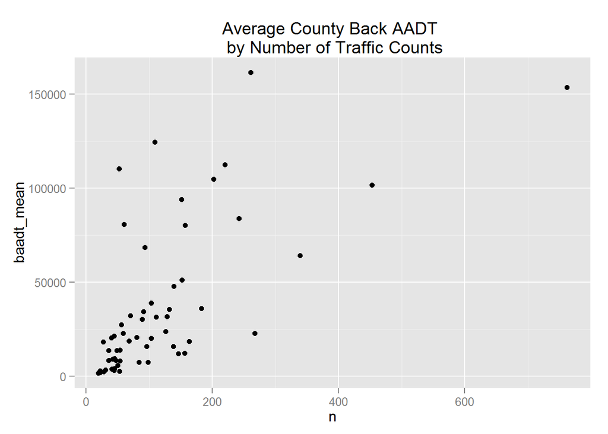

```
##
##  Pearson's product-moment correlation
##
## data:  n and baadt_mean
## t = 6.6872, df = 56, p-value = 1.136e-08
## alternative hypothesis: true correlation is not equal to 0
## 95 percent confidence interval:
##  0.4928630 0.7888568
## sample estimates:
##       cor
## 0.6663318
```

```
##
##  Pearson's product-moment correlation
##
## data:  log10(pop20120701) and log10(baadt_mean)
## t = 18.5323, df = 56, p-value < 2.2e-16
## alternative hypothesis: true correlation is not equal to 0
## 95 percent confidence interval:
##  0.8796410 0.9564716
## sample estimates:
##      cor
## 0.927257
```

```
##
##  Kendall's rank correlation tau
##
## data:  log10(pop20120701) and log10(baadt_mean)
## z = 8.66, p-value < 2.2e-16
## alternative hypothesis: true tau is not equal to 0
## sample estimates:
##       tau
## 0.7810042
```

```
##
##  Spearman's rank correlation rho
##
## data:  log10(pop20120701) and log10(baadt_mean)
## S = 2232, p-value < 2.2e-16
## alternative hypothesis: true rho is not equal to 0
## sample estimates:
##       rho
## 0.9313421
```

It looks like the Pearson and Spearman correlation is slightly higher using the Annual Average and not peak daily traffic, but the Kendall correlation is slightly lower.

Now we can try to do a linear model.

```
##
## Call:
## lm(formula = baadt_mean ~ pop20120701, data = dfp3.baadt_by_county)
##
## Residuals:
##    Min     1Q Median     3Q    Max
## -71003 -16400  -6743   3077  79446
##
## Coefficients:
##              Estimate Std. Error t value Pr(>|t|)
## (Intercept) 2.366e+04  4.038e+03   5.860 2.57e-07 ***
## pop20120701 2.020e-02  2.575e-03   7.845 1.39e-10 ***
## ---
## Signif. codes:  0 '***' 0.001 '**' 0.01 '*' 0.05 '.' 0.1 ' ' 1
##
## Residual standard error: 27960 on 56 degrees of freedom
## Multiple R-squared:  0.5236, Adjusted R-squared:  0.5151
## F-statistic: 61.54 on 1 and 56 DF,  p-value: 1.392e-10
```

```
##
## Call:
## lm(formula = log10(baadt_mean) ~ log10(pop20120701), data = dfp3.baadt_by_county)
##
## Residuals:
##      Min       1Q   Median       3Q      Max
## -0.37008 -0.15914 -0.03735  0.12866  0.49741
##
## Coefficients:
##                    Estimate Std. Error t value Pr(>|t|)
## (Intercept)         1.11676    0.17377   6.427 3.05e-08 ***
## log10(pop20120701)  0.60937    0.03288  18.532  < 2e-16 ***
## ---
## Signif. codes:  0 '***' 0.001 '**' 0.01 '*' 0.05 '.' 0.1 ' ' 1
##
## Residual standard error: 0.1963 on 56 degrees of freedom
## Multiple R-squared:  0.8598, Adjusted R-squared:  0.8573
## F-statistic: 343.4 on 1 and 56 DF,  p-value: < 2.2e-16
```

Both models show high significance that some relationship exists between traffic and population. The standard error should be at least an order of magnitude lower than the coefficient estimate and it is approximately so for both models. R squared is higher for the log-log model, which means it fits better.

Next I tried to plot traffic per population (ahead_peak_hour/county_pop). I noticed that Sierra county had some high outliers - this county does not have a large population but it does have I-80 which gets a lot of traffic.

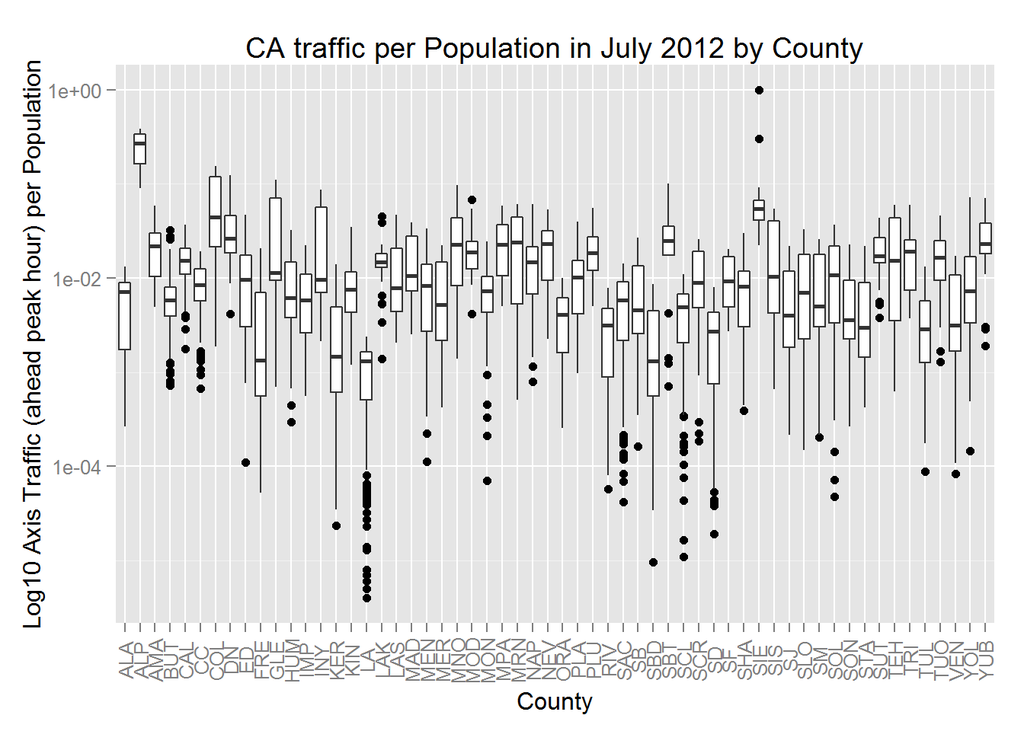

Now order the counties by the number of traffic counts per county (descending).

When it is not plot on log scale, there is a huge outlier for Sierra County. But it looks like traffic does not go up linearly with population - because LA has such a large population, it has a very small traffic count/population ratio.  
Alpine has a large ratio - either it has a lot of visitors, or 1/4 of the population drives on each state route.

I plot it again in log scale.

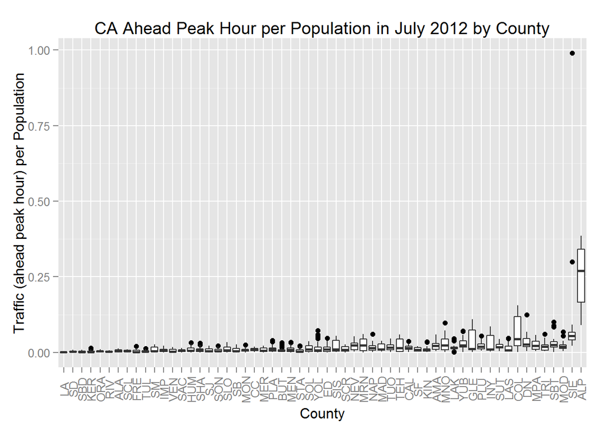

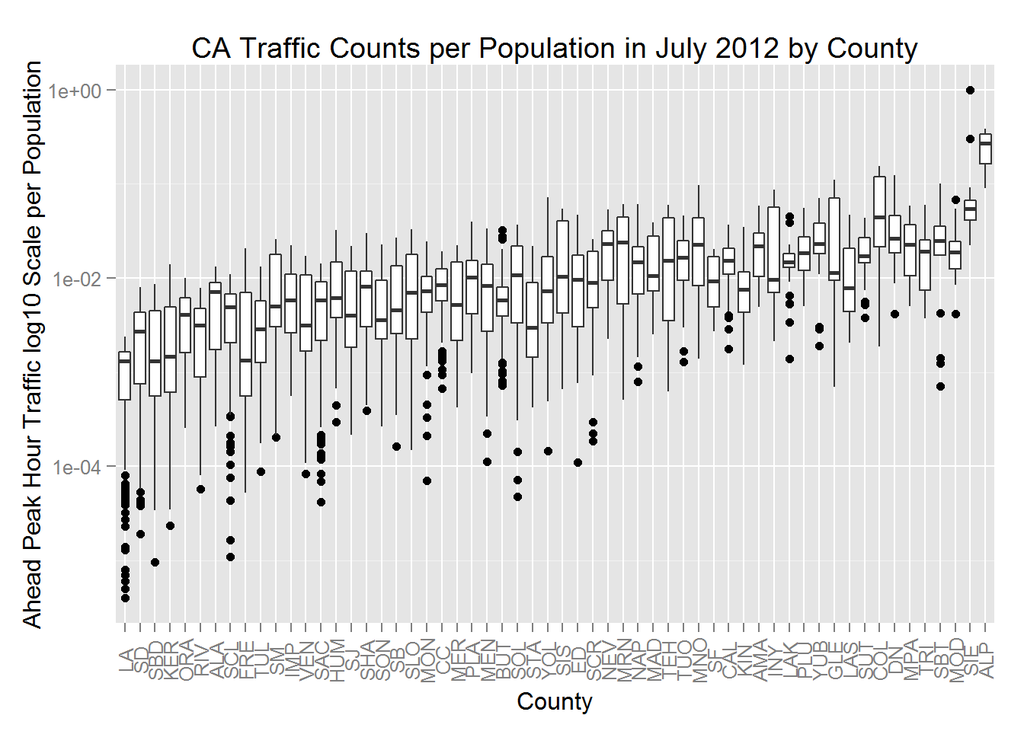

Now I am doing some investigations from my cumulative mileage on Highway 101 plot, investigating descriptions to find causes for fluctuations in traffic. Looking at S Santa Barbara and Santa Clara counties. Looks like AAA Triptik!

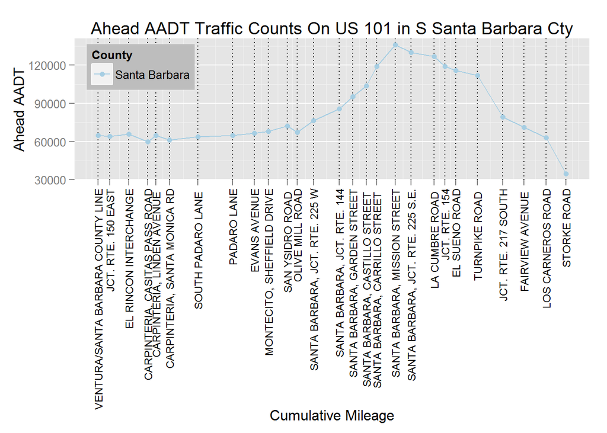

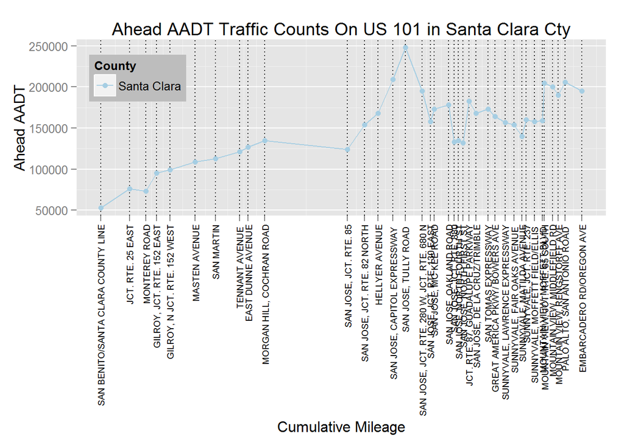

# Multivariate Analysis

### Talk about some of the relationships you observed in this part of the investigation. Were there features that strengthened each other in terms of looking at your feature(s) of interest?

Looking at Descriptions helped me understand the traffic flows more, but not in a statistical way. If I had some text analysis I could have actually used the descriptions more. It might also have helped to know how many lanes were in the highways at each point.

My early investigations did a lot of investigations by county since that was a convenient feature to use. Later I was able to add the county populations, which helped to clarify why certain counties were showing certain properties - it was based at least somewhat on their population. These two features are not independent, but since population is numeric, it helps to quantify the relationship.

I also saw how the back and ahead traffic counts in an intersection could vary, but they were seemingly normal.

### OPTIONAL: Did you create any models with your dataset? Discuss the strengths and limitations of your model.

I created a model to predict average traffic for a county based on the county population. Since I only had average population across the entire county, it couldn’t be too accurate - the traffic fluctuates in a county. It actually uses the log of the population vs. the log of the traffic. It could be made stronger perhaps if I had more data about the type of roadway (number of lanes, etc.) and more demographic information.

# Final Plots and Summary

### Plot One

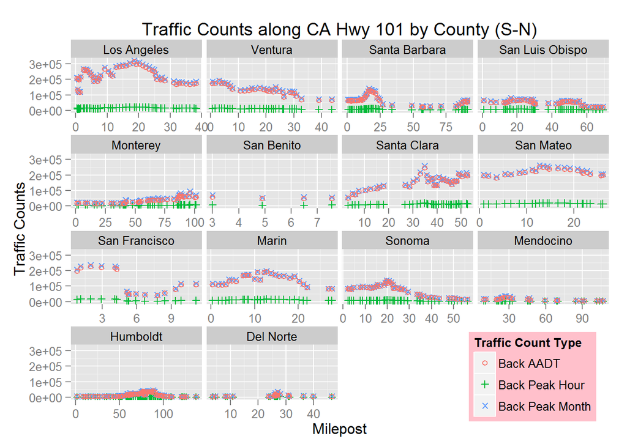

### Description One

This is a faceted plot of the three back traffic types along Highway 101 by county. The mileposts run from South to North. Each count type has a different shape and color. I kept the y (traffic count) axis the same for all counties so they could be compared, but let the x (postmile) axis free so some counties are more spaced out.

This plot type, unlike the unfaceted plot later, lets the 3 traffic types show clearly in each county, although the scale doesn’t allow you to see much variation in hourly traffic.  
Back peak hour traffic is always lower than the other two, which measure entire days. The traffic hits its peak in Los Angeles county where counts are closely spaced together, and then decreases through the rest of Los Angeles and Ventura counties. There is a local peak in Santa Barbara and counts are father apart in the middle of Santa Barbara. They start rising slightly travelling North in Monterey, and increase more in Santa Clara and San Mateo, before peaking in San Mateo county and starting to decrease. There is a big drop in San Francisco county, as Highway 101 goes through the city - further investigation is warranted.

Looking at the raw traffic data, the drop occurs at the junction with I-80 (Bay Bridge), before S. Van Ness Avenue - a city street does not have the same capacity as a highway and much of the traffic continues to I-80.

Traffic increases when approaching the Golden Gate Bridge and then peaks in Marin County in San Rafael, peaks (but lower) in Sonoma county in Santa Rosa, and then decreases to lower levels in the northern counties.

### Plot Two

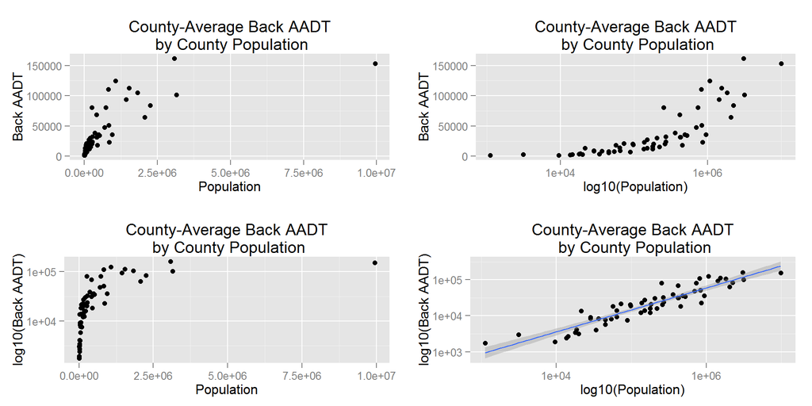

### Description Two

This plot shows the attempt to find a relationship between average traffic on county roadways and the population of the county. The AADT is the Annual Average Daily Traffic - the total volume for the year divided by 365 days. My assumption is that a county with higher population would have higher average traffic counts. This might not always be the case because some cities have higher public transportation usage.

I looked at the County-Average (mean) back (south or west of the intersection) average anual daily traffic vs. county population. I could see a relationship, but it wasn’t exactly linear. It looked vaguely logarithmic so I plotted the logs of each variable against the other and they still didn’t look linear. Plotting logs of both traffic and population made it look linear. I show a grid of all four plots here to show my thought process. I added a lm line to the plot to show the relative linearity of this model.

My assumption is that the daily average would have a higher correlation to population than the daily or seasonal peak, since it isn’t a peak that could be influenced by tourists or commuters.

### Plot Three

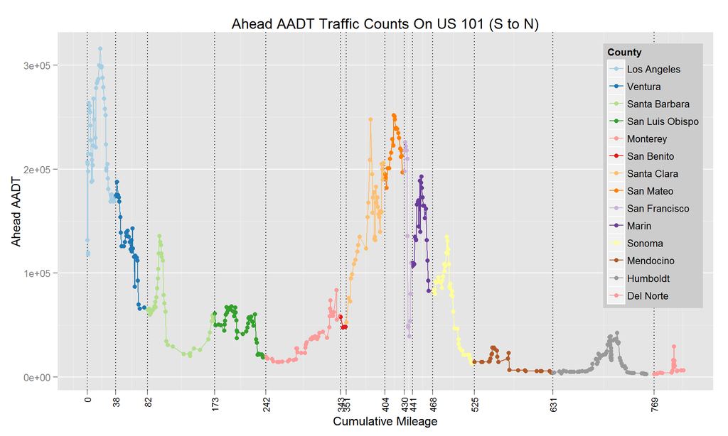

I used a palette that provides a contrast between neighboring counties, instead of the standard palette. It was difficult to find a palette like that which had enough colors, so I had to add two manually.

This plot shows how the traffic varies with location. I also did a subplot for part of Santa Barbara (in multiplot section) where I included the location description, which demonstrates what is going on at the location.

This plot shows that Los Angeles county has some of the highest average daily traffic. It does a better job of showing how the traffic compares along the entire route than the facetted plot does. The traffic increases around the San Francisco Bay Area. The northern part of the state has the lowest traffic.

### Plot Four

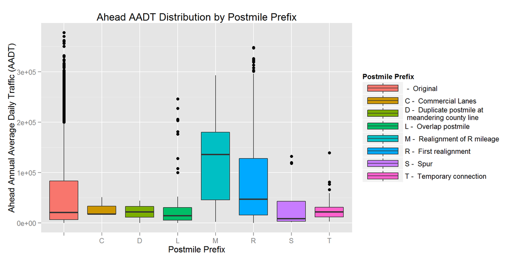

### Description Four

Another thing that could be added is the relative count of each postmile prefix - how to best represent that along with the distributions? Or we could compare future years to see how realignments increase over time relative to traffic counts or population.

# Reflection

My biggest struggle in this analysis was knowing when to quit. Even now, I keep finding more things I would like to investigate and different ways I can improve what I’ve already done, but I’ve been working on this for over 3 weeks and would like to finish. When I first picked the dataset, I wasn’t sure it was good enough. I didn’t know what I could model. I had some suggestions to add population data and that really helped make it more interesting.

For a long time I struggled with how to present the data. I wanted to show traffic patterns along a highway, and my first approach was to facet it by county. I didn’t realize I could free the scales so that different counties could have different lengths. I had to gradually learn the features of ggplot2 and dplyr to be able to do what I wanted it to do. So in the beginning, I used some not-polished coding and as I went along and tried to do more things I learned more and changed my way of doing things. But I did not always go back and update what I had already done, so you can see different levels of skills in the work.

My biggest struggle will be to organize the plots in a logical order and comment them all. With a single laptop screen and a broken printer, I have no easy way to go through it. When I printed out my final and needed to make changes, I inadvertently deleted some text and didn’t catch it at the end because I could not print it out again before I submitted.

Thank you to Olivia and all the other TA’s who helped me on this journey!